# How does SNSF research relate to the UN Sustainable Development Goals?

13.04.2023

**The SNSF performed an exploratory analysis to determine the extent to which the projects it funds are related to the UN Sustainable Development Goals. The analysis found evidence of links to the Goals in all research areas. A survey of researchers is set to provide further insights.**

The aim of the United Nations’ 17 Sustainable Development Goals (SDGs) is to promote human wellbeing in an equitable way such that no one gets left behind and the natural systems are protected. Research has an important role to play here. It generates new knowledge and, by so doing, lays the foundations for technological and social innovation. Thus, it contributes to the social and political discourse on concerted action and attitude change.

We used two labelling systems to conduct an exploratory analysis aimed at determining the SDG relevance of SNSF grants. Although the labelling systems still require further development (see “Method and limitations” box), the results give an initial insight into the relationship between SNSF-funded research and the SDGs.

### Method and limitations

We tested various SDG labelling systems for our analysis: the Dimensions SDG classifier as well as the labelling systems available via the publicly accessible [text2sdg](https://github.com/dwulff/text2sdg#readme) [R package](https://www.r-project.org/about.html) (Aurora, Elsevier, OSDG, SDSN and SIRIS). The titles, abstracts and keywords of the grants were fed into each of these tools. We evaluated a random sample of the results generated by the various systems. This involved identifying the SDGs to which – from our perspective – the grants were linked and comparing our assessment with the results produced by the systems. Thus, we were able to determine which systems identified the “correct” SDGs and delivered the fewest false-positive results. A false-positive occurs when the labelling system identified a relationship with a particular SDG that does not match in reality. We concluded that the Dimensions and Elsevier systems produced the best results with the SNSF data. The approaches used by Dimensions and Elsevier are briefly explained below.

Dimensions  
The Dimensions classifier is based on machine learning and was developed by Digital Science. Using [Dimensions](https://www.dimensions.ai/), the world’s largest linked research information dataset (publications, funding, research data, etc.), [Digital Science built a model from the 17 SDGs](https://digitalscience.figshare.com/ndownloader/files/22574228), using an approach that relied on creating and curating extensive and targeted search queries. This was used to generate 17 publication training sets from the Dimensions database (one for each SDG), and natural language processing was applied to create an SDG classification scheme. To improve the quality of the training sets, the results were repeatedly examined by ensuring the publications fit the description of the SDG definition. The Dimensions classifier also applies a proximity search to some of its search queries to ensure that sentences containing certain related words can also be found.[^1]

Elsevier  
Elsevier’s data science team has also [developed a set of queries related to the SDGs](https://elsevier.digitalcommonsdata.com/datasets/87txkw7khs/1). These are based on [Scopus](https://www.scopus.com/), Elsevier’s abstract and citation database for scientific literature. Working with specialists, an initial Scopus search query was developed for each SDG. This produced a curated list of publications related to the SDGs. The process of refining the queries for each SDG is still ongoing. Elsevier uses customer feedback to increase the number of search terms used to define the individual SDGs. A machine learning model was added to the queries in a more recent version dating from 2021/2022. We used the original version from 2019 for the analyses in this data story. Elsevier does not include SDG 17 (Partnerships for the Goals) in its labelling system. Since we only consider cases where both labelling systems identify the same SDG (see the description of the approach in the next section), SDG 17 has also been excluded from our analysis.

**Limitations**  
Using automatic labelling systems to identify links to the SDGs has limitations. Firstly, not all links to the SDGs are identified correctly. Secondly, the tools occasionally identify links where there are none. Moreover, the tools are generally more sensitive to one or more of the SDGs and overestimate their prevalence. In addition, it is not yet possible to make a final assessment of the quality of the labelling systems, since very few sufficiently large validation data sets are currently available.[^2]  
In light of this, we decided to adopt a cautious approach, comparing the results obtained from Dimensions and Elsevier, and only deeming a link to an SDG valid if both tools had recognised it. This method was intended to produce a suitable lower bound that can be used to identify trends over time and reduce the problem of false-positive results. Although the methods and results are experimental, we believe that they are interesting nevertheless, since both tools set out to measure the same thing, are based on similar approaches and deliver comparable results.  
In the meantime, the authors of the text2sdg R package have developed an “[ensemble model](https://arxiv.org/pdf/2301.11353.pdf)” that brings together different labelling systems. This could potentially outperform our approach. We welcome this and will follow its development closely.

Comparison of the two labelling systems: percentage of grants approved from 2016 to 2021 that have a link to an SDG

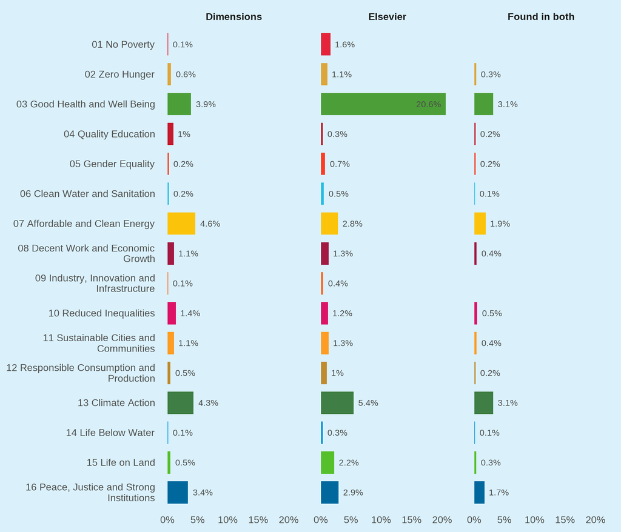

Data: Approved grants 2016–2021.

### All research areas are conducting research related to the Sustainable Development Goals

The labelling system identified a link to one or more SDGs in 1,489 out of a total 12,431 grants (12%) approved since 2016 (see figure below). These grants received funding totalling 709 million Swiss francs or 13% of the funding awarded. A link to more than one SDG was identified in very few cases. Links to two SDGs were identified in 70 grants (0.6%) and just two grants were found to have a link to three SDGs.

Approved grants 2016–2021 where a link to one or more SDGs was identified (percentage of grants and percentage of approved funding)

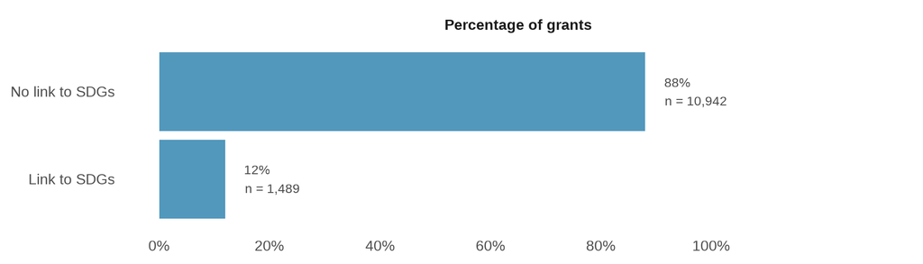

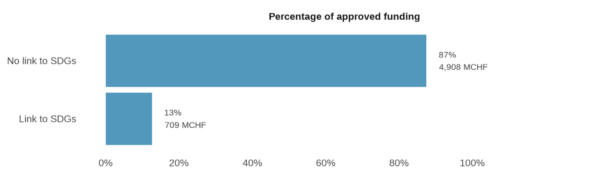

Data: Approved grants 2016–2021.

Approved grants 2016–2021 where a link to one or more SDGs was identified (percentage of grants and percentage of approved funding)

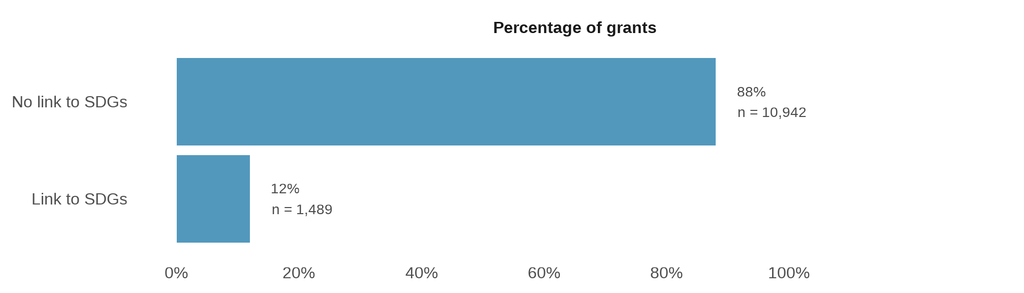

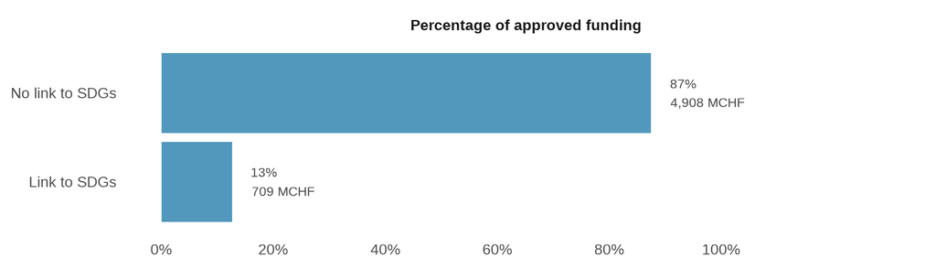

Data: Approved grants 2016–2021.

Overall, there has been a slight upwards trend since 2016. The labelling system indicates an increasing number of grants with a link to the SDGs and thus also a greater investment of financial resources towards SDG research. There are no major differences between research areas (social sciences and humanities: SSH, mathematics, natural and engineering sciences: MINT and life sciences: LS).

Trends in percentage of grants where a link to one or more SDGs was identified (percentage of grants and percentage of approved funding)

[interactive chart not shown]

Data: Approved grants 2016–2021.

Trends in percentage of grants where a link to one or more SDGs was identified (percentage of grants and percentage of approved funding)

[interactive chart not shown]

Data: Approved grants 2016–2021.

### Most research on climate action and health

Using the labelling system, we were able to identify the SDGs addressed by SNSF grants. Links were most frequently identified for the following six SDGs:

- SDG 13: Climate Action (3.1% of all grants analysed)
- SDG 3: Good Health and Well-Being (3.1%)
- SDG 7: Affordable and Clean Energy (1.9%)
- SDG 16: Peace, Justice and Strong Institutions (1.7%)
- SDG 10: Reduced Inequalities (0.5%)
- SDG 11: Sustainable Cities and Communities (0.4%)

Percentage of grants approved between 2016 and 2021 by SDG

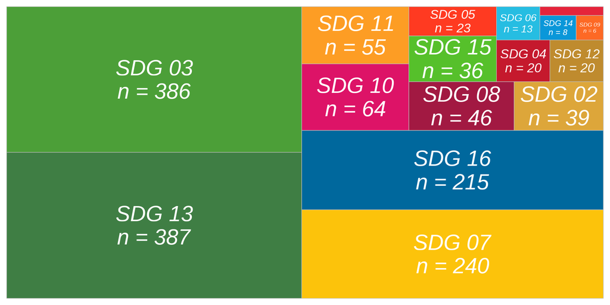

Data: Approved grants 2016–2021.

Percentage of grants approved between 2016 and 2021 by SDG

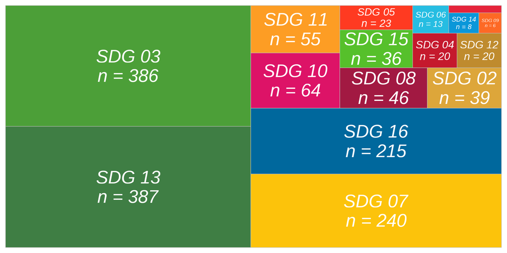

Data: Approved grants 2016–2021.

Which research areas address those SDGs? There appears to be one “dominant” research area for each of the top three SDGs; however, the two other areas also contribute to research into the issue in question. SDG 16 (Peace, Justice and Strong Institutions) and SDG 10 (Reduced Inequalities) appear to be more or less exclusively the domain of the social sciences and humanities (SSH). In contrast, SDG 11 (Sustainable Cities and Communities) was shared in similar proportions by SSH and MINT (mathematics, natural and engineering sciences), with the life sciences (LS) also playing a small role.

Contribution of the three research areas to the top six SDGs

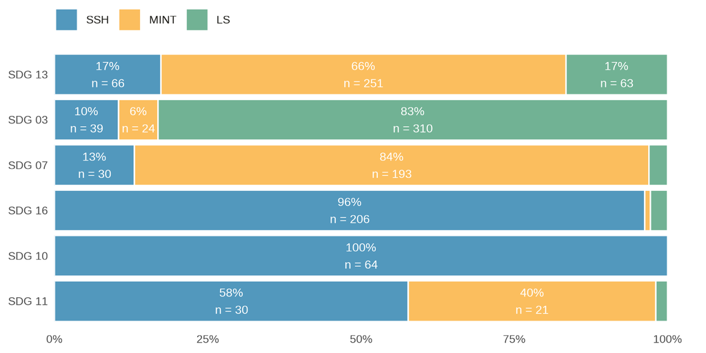

Data: Approved grants 2016–2021.

Contribution of the three research areas to the top six SDGs

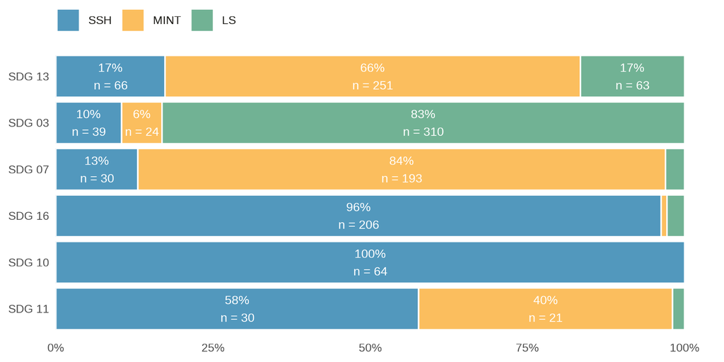

Data: Approved grants 2016–2021.

### Research into affordable and clean energy: several contributing disciplines

Below we take a closer look at SDG 7 (Affordable and Clean Energy) – a very topical issue. According to the labelling system, 240 (1.9%) of all the grants analysed have a link to this SDG. The associated financial resources amount to 108 million Swiss francs.

Just under half (44%) of these grants involve several participating disciplines. This is also the case for the other SDGs: almost half of the grants (47%) with an identified link to an SDG involved several participating disciplines. Grants with several disciplines only account for 41% of all the grants funded by the SNSF, and so this finding reinforces the [hypothesis](https://www.nature.com/articles/525315a) that collaboration across disciplinary boundaries is particularly important for addressing global challenges. Complex issues require collaboration, consensus-building, validation, cross-fertilisation of ideas and effective communication beyond scientific disciplines.

Number of disciplines involved in grants with an identified link to SDG 7 (Affordable and Clean Energy)

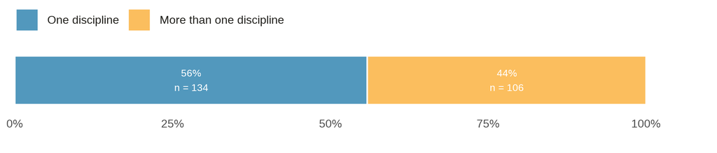

Data: Approved grants 2016–2021 with a link to SDG 7.

Number of disciplines involved in grants with an identified link to SDG 7 (Affordable and Clean Energy)

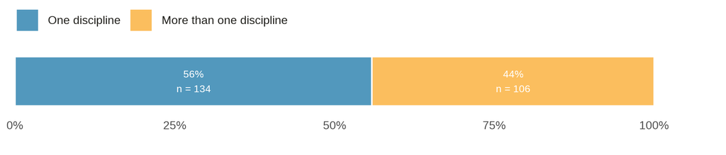

Data: Approved grants 2016–2021 with a link to SDG 7.

The most frequent combinations of disciplines in grants with an identified link to SDG 7 were:

- Chemistry and engineering science (46 grants, 43% of grants with several disciplines) ;
- Physics and engineering science (15 grants, 14%) ;
- Chemistry and physics (13 grants, 12%).

Frequently, two or more applicants are working together in these grants. Thus, 23% of grants with a link to SDG 7 are collaborative. This same percentage applies across all grants with a link to an SDG (23%). Across all the grants studied, the share of collaborative grants is only 19%.

Level of collaboration in grants with an identified link to SDG 7 (Affordable and Clean Energy)

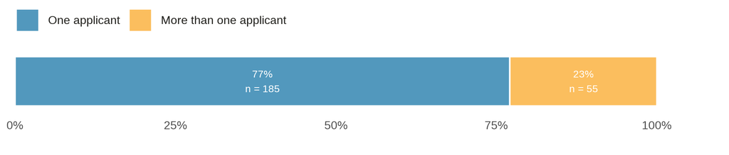

Data: Approved grants 2016–2021 with a link to SDG 7.

Level of collaboration in grants with an identified link to SDG 7 (Affordable and Clean Energy)

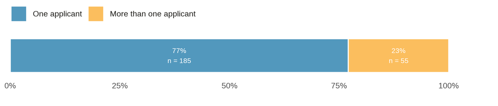

Data: Approved grants 2016–2021 with a link to SDG 7.

A total of 152 applicants were involved in the 55 collaborative grants with a link to SDG 7. The most common form of collaboration was between Swiss and foreign institutions. This type of international collaboration was found in 28 grants.

### 2023: Launch of a survey on SDGs

As mentioned above, the labelling systems used are still under development, and we are thus unable to determine with complete certainty how many grants are actually linked to the SDGs. To obtain a better and more complete overview, the SNSF will launch a survey in 2023 to ask corresponding applicants about any specific contributions their grants make to the SDGs. By doing so, we hope to obtain a systematic overview and identify gaps in current knowledge about sustainable development. We can then launch suitable initiatives to stimulate research projects that will fill these gaps and contribute to the achievement of the SDGs.

### Data

This analysis is based on the titles, abstracts, and keywords from grant proposals funded between 2016 and 2021. Scientific communication projects – Scientific Exchanges, Agora, open-access fees and publication grants – have been excluded. The National Centres of Competence in Research (NCCRs) have also been excluded because they have a different structure. A total of 12,431 grants were analysed.

**Grants involving several disciplines** were identified using the information supplied by the applicants (primary and secondary disciplines, see [disciplines list](https://www.snf.ch/SiteCollectionDocuments/allg_disziplinenliste.pdf)). The SNSF discipline list comprises three levels. At the overarching level are the three research areas – social sciences and humanities (SSH), mathematics, natural and engineering sciences (MINT) and the life sciences (LS). The middle level refines these research areas, and the third level disciplines have an even finer granularity. If a grant lists at least two different middle level disciplines, we define it as a grant involving several disciplines.

A **collaborative grant**, is one in which at least two applicants participate. This comprises one corresponding applicant and at least one other applicant.

**Links to more information**

[Sustainable development](https://www.snf.ch/en/3DEoAgSx2yMXZaAX/topic/sustainable-development)

Data, text and code of this data story are [available on Github](https://github.com/snsf-data/datastory_snf_research_and_sdgs) and [archived on Zenodo](https://doi.org/10.46446/datastory.snf-research-and-sdgs).  
DOI: 10.46446/datastory.snf-research-and-sdgs

[^1]: Wastl J, Hook DW, Fane B, Draux H, Porter SJ. 2020. Contextualizing Sustainable Development Research. Using Dimensions to explore the global landscape of research on Sustainable Development Goals. Digital Science. Report. https://doi.org/10.6084/m9.figshare.12200081.v2
[^2]: Wulff DU, Meier DS, Mata R. 2023. Using novel data and ensemble models to improve automated labeling of Sustainable Development Goals. Preprint: https://arxiv.org/pdf/2301.11353.pdf